# Lecture 11: Ensembles

## Announcements

- Final Exam Dates

## iClicker Exercise 11.0

Which of the following scenarios has worked effectively for you in the past?

- 1. Working independently on a project/assignment.
- 2. Working with like-minded people.
- 3. Teaming up with a diverse group offering varied perspectives and skills.

## [The Wisdom of Crowds](http://wisdomofcrowds.blogspot.com/2009/12/introduction-part-i.html)

Groups can often make better decisions than individuals, especially when group members are diverse enough.

[figure not shown]

## Ensembles key idea

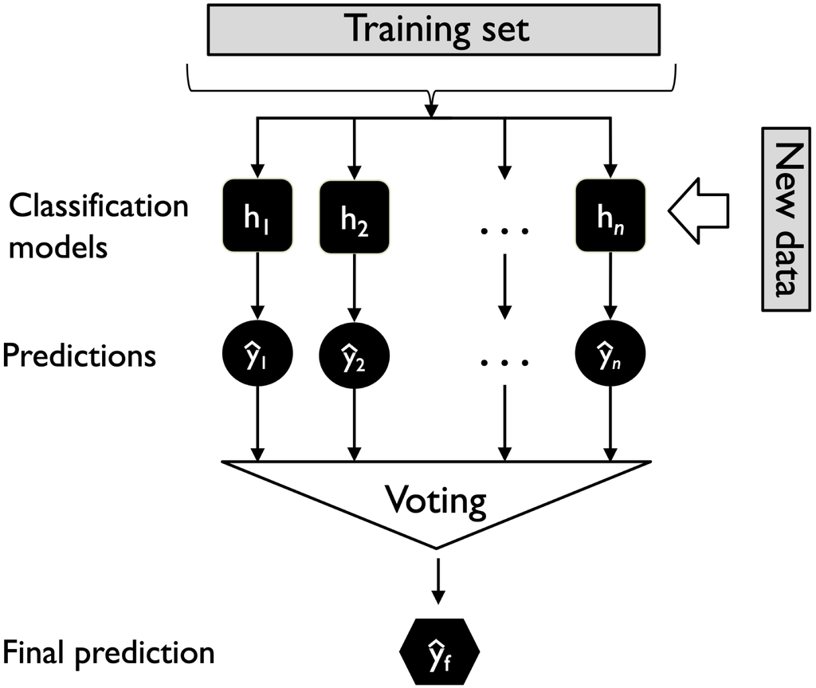

[Source](https://sebastianraschka.com/pdf/lecture-notes/stat451fs20/07-ensembles__slides.pdf)

- Combine predictions from multiple models for a more accurate and stable result
- Classification: either take majority class or average predicted probabilities
- Regression: Average (mean or median) predictions
- Averaging reduces individual model errors, making the ensemble more robust than any single model

## Ensembles

- Ensemble methods are **widely used in industry** and dominate **machine learning competitions** (e.g., Kaggle).
- In this course, we’ll explore
- **Tree-based ensembles:**
  - Random Forests
  - Gradient Boosted Trees (at a high level)
- **Ways to combine models:**
  - **Averaging:** combine model outputs directly
  - **Stacking:** use one model to learn how to combine others

## When do ensembles help?

In which of these scenarios does an ensemble improve performance?

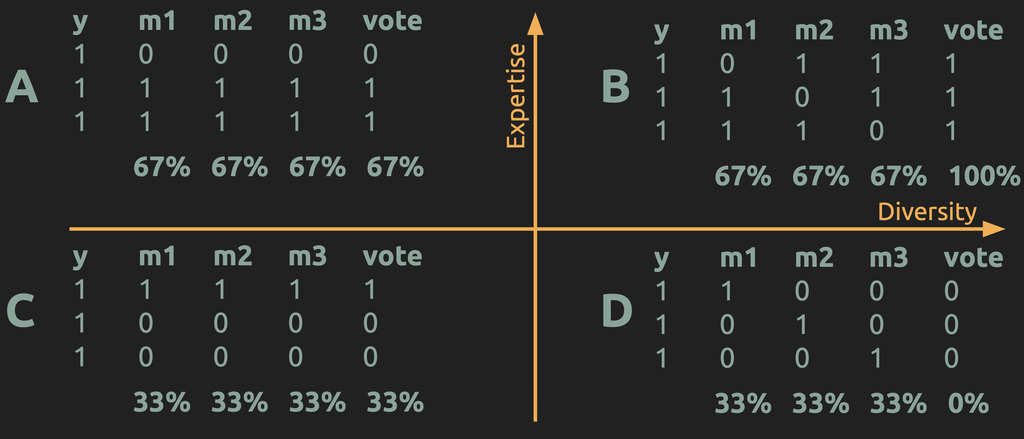

Source

## When do ensembles help?

Ensembles improve performance when the individual models are both **competent** (have expertise) and **make different kinds of errors** (are diverse).

## Diversity

- Ensembles work best when their models make **different types of mistakes**.
- If all models make the same errors, averaging won’t help.
- We can **encourage diversity** by:
  - Introducing randomness (e.g., bootstrapped samples and random feature subsets (*Random Forests*))
  - Sequentially focusing on previous errors (e.g., *Gradient Boosting*)

## Expertise

- Diversity alone is not enough. Individual models should still have **some predictive skill**.
- If each model performs poorly (worse than random), the ensemble can’t recover.
- Best ensembles strike a **balance** between:
  - **Diversity:** models disagree in useful ways
  - **Expertise:** each model performs better than chance

# Random forest

## What can we randomize between trees?

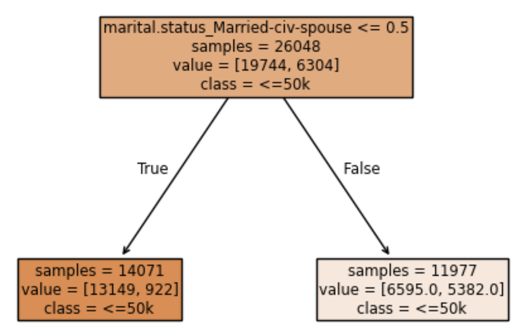

## Two sources of randomness in random forests

- **Bootstrap sampling of data**  
  Each tree is trained on a slightly different dataset → decorrelates trees.
- **Random subset of features at each split**  
  Each split considers only a random subset of features → further reduces correlation.

## Bootstrap sample

- Ensures trees **see different versions of the data**
- Creates **diversity** while preserving **similar overall structure**

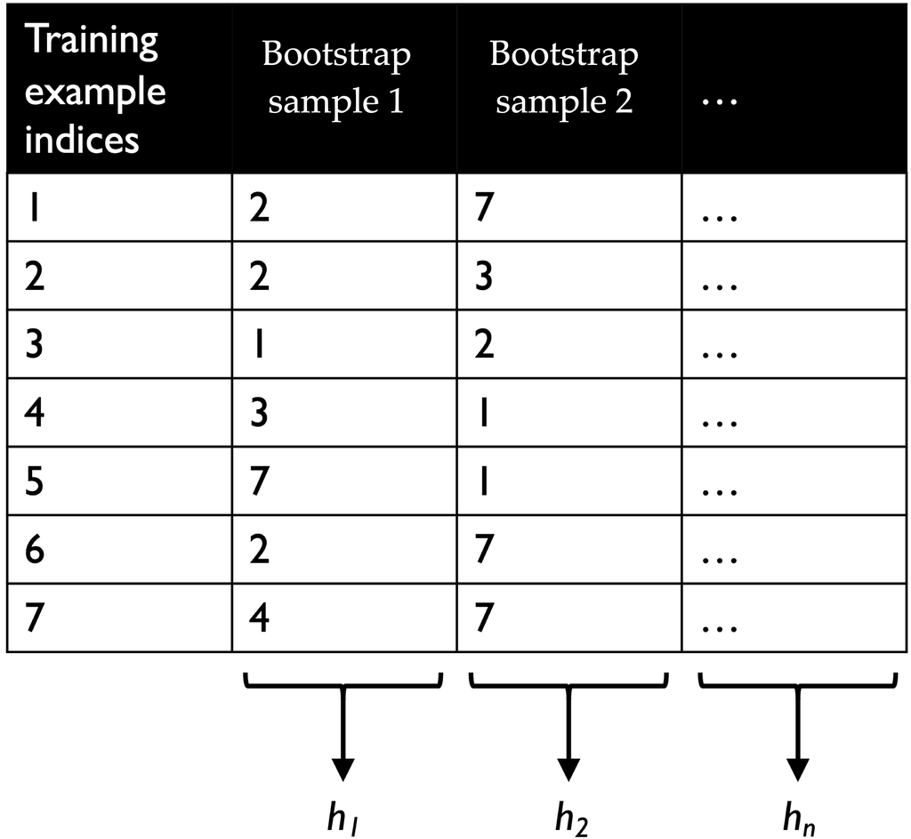

[Source](https://sebastianraschka.com/pdf/lecture-notes/stat451fs20/07-ensembles__slides.pdf)

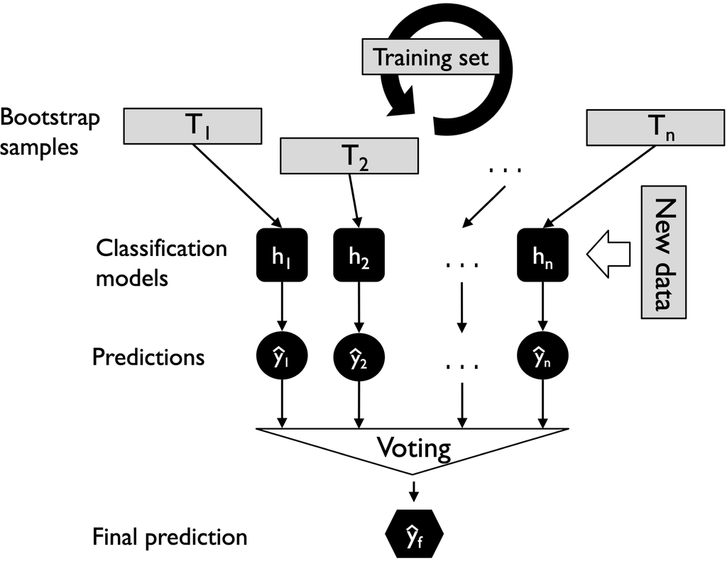

## Random subset of features at each split

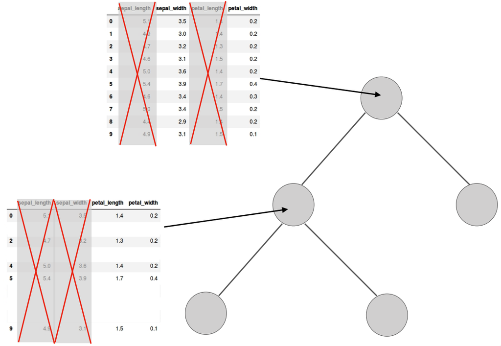

[Source](https://sebastianraschka.com/pdf/lecture-notes/stat451fs20/07-ensembles__slides.pdf)

- Select a different subset of features at every split
- Each tree now explores different parts of the feature space
- 🤔 But why not pick one subset per tree instead?

## Why use a new subset at each split?

| Strategy | Diversity | Expertise | Issue |
| --- | --- | --- | --- |
| One subset per tree | Very high | Often low | May miss important features |
| New subset per split | Moderate | High | Stronger, less correlated trees |

- Using a new subset per split strikes a **balance** between diversity and strength
- Prevents trees from becoming too weak while still keeping them different

> “Random selection of features at each node gives substantial additional accuracy gains over bagging alone.”  
> — *Breiman (2001)*

## Interim summary

- Random Forests reduce overfitting by **decorrelating trees**
- Two ingredients make this happen: Random data (bootstrapping) and random features (per split)
- Together, they build a strong yet diverse ensemble

## iClicker Exercise 11.1

**Select the most accurate option below.**

- 1. Every tree in a random forest uses a different bootstrap sample of the training set.
- 2. To train a tree in a random forest, we first randomly select a subset of features. The tree is then restricted to only using those features.
- 3. The `n_estimators` hyperparameter of random forests should be tuned to get a better performance on the validation or test data.
- 4. In random forests we build trees in a sequential fashion, where the current tree is dependent upon the previous tree.
- 5. Let classifiers A, B, and C have training errors of 10%, 20%, and 30%, respectively. Then, the best possible training error from averaging A, B and C is 10%.

# Gradient boosting (high level)

## From random forests to boosting

- In **random forests**, we build trees **independently** and **average** their predictions
  - reduces **overfitting** by combining diverse models
- In **boosting**, we build trees **sequentially**
  - each new tree **learns from the mistakes** of the previous ones
  - reduces **underfitting** by making the model smarter over time

## Why it works

- **Sequential correction:** each tree improves on what’s left of the error
- **Bias reduction:** starts simple and **adds complexity gradually**
- **Controlled learning:** small trees and a learning rate prevent overfitting

## Most commonly used boosting models

- **XGBoost:** extremely optimized and widely adopted in industry
- **LightGBM:** faster training with large datasets
- **CatBoost:** handles categorical features efficiently

> *“More recently, gradient boosting machines (GBMs) have become a Swiss army knife in many a Kaggler’s toolbelt.”*  
> — Sebastian Raschka, Joshua Patterson, & Corey Nolet (2020)

# Averaging and Stacking

Goal: Combining diverse models for better generalization

## Averaging (Voting)

- Combines predictions from **multiple base models**
- Works for both **classification** and **regression**
- Improves stability and performance by averaging over models
- Random forest is a type of averaging classifier

## Types of Voting

**Hard Voting**

- Each model votes for a class label
- Final prediction = **majority vote**

**Soft Voting**

- Averages the **predicted probabilities** from each model
- Final prediction = class with **highest average probability**
- Usually performs better

## Stacking

- Goes one step beyond averaging
- Instead of simple averaging, trains a meta-model to learn how to best combine base models’ predictions

## How stacking works

- Train several base models on the training data
- Collect their predictions on a validation set
- Train a meta-model on those predictions to learn the optimal combination
- Final prediction = output of the meta-model

## Stacking

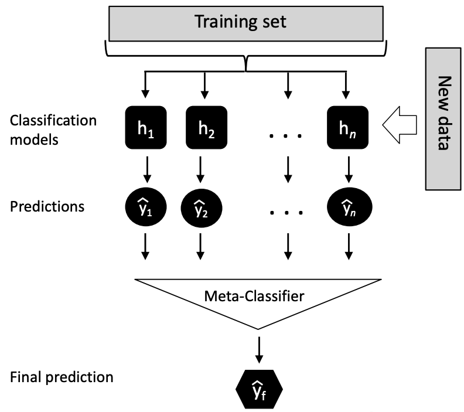

[Source](https://sebastianraschka.com/pdf/lecture-notes/stat451fs20/07-ensembles__slides.pdf)

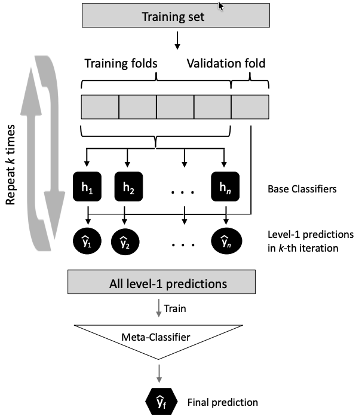

## Break

Let’s take a break!

[figure not shown]

/

## Group Work: Class Demo & Live Coding

For this demo, each student should [click this link](https://github.com/new?template_name=lecture11_demo&template_owner=ubc-cpsc330) to create a new repo in their accounts, then clone that repo locally to follow along with the demo from today.